# clean_data.Rmd

# Read in Data

We manually pulled a csv out of Alchemer and stored that data in a Google Sheet, along with some manually created helper tabs for translating column names and coding free text data.

```r
# currently using interactive/ in browser auth
# whoever is running this code must have access to the gsheet
url <- 'https://docs.google.com/spreadsheets/d/1Txd27HY5Fc8MTcKGM_U1mOuRIrgjJtU7w1CSJxdvC3M'

df <- googlesheets4::read_sheet(url, sheet = '2/22: Data')
```

[output not shown]

[output not shown]

[output not shown]

[output not shown]

```
## Reading from "2/7 Survey Responses "
```

```
## Range "'2/22: Data'"
```

[output not shown]

```r
columns <- googlesheets4::read_sheet(url, sheet = 'Columns')
```

```
## Reading from "2/7 Survey Responses "
```

```
## Range "'Columns'"
```

```r
questions <- googlesheets4::read_sheet(url, sheet = 'Questions')
```

```
## Reading from "2/7 Survey Responses "
```

```
## Range "'Questions'"
```

```r
freetext <- googlesheets4::read_sheet(url, sheet = 'Free Text')
```

```
## Reading from "2/7 Survey Responses "
```

```
## Range "'Free Text'"
```

```
## * `` -> ...5
```

```r
# reference data
# real purchasing power by metro statistical area (MSA), downloaded from
# https://apps.bea.gov/iTable/iTable.cfm?reqid=70&step=30&isuri=1&major_area=5&area=xx&year=2019&tableid=104&category=8101&area_type=0&year_end=-1&classification=non-industry&state=5&statistic=1&yearbegin=-1&unit_of_measure=levels

rpp <- readr::read_csv(
  # first 4 lines are notes, not data, so skip
  here::here("data", "rpp_by_msa_2019.csv"), skip = 4) %>%
  clean_names() %>%
  rename(
    cbsa = geo_fips,
    rpp = x2019
  ) %>%
  # last 3 lines are notes that caused the parsing failure, so drop
  filter(!is.na(rpp))
```

```r
# geographic info for zip to CBSA downloaded from
# https://www.huduser.gov/portal/datasets/usps_crosswalk.html#data
geo <- readr::read_csv(here::here("data", "zip_to_cbsa.csv"))  %>%
  clean_names()
```

# Clean Column Names

## Create Helper DF of Clean Column Names

We manually re-coded column names in the above google sheet, with one tab at the question level and one tab at the response level, to deal with multi-select questions that are stored spread across multiple columns.

Now, we need to join the question and response level tabs together to form a complete key, then use the values in that key to replace the column names currently on the main dataframe.

```r
# create useful column names for multi-select questions
# format: question_name.resp.response_text
# later on, we will use the .resp. separator to transform only these cols

name_helper <- questions %>% full_join(
  columns,
  by = "question_name"
) %>% mutate(
  col_name_final = stringr::str_c(
    snakecase::to_snake_case(question_name_short),
    ".resp.",
    snakecase::to_snake_case(col_name_clean)
  )
) %>% mutate(
  col_name_final = coalesce(
    col_name_final,
    snakecase::to_snake_case(question_name_short)
  )
) %>% unique()

# clean up environment
rm(columns, questions)
```

## Remove Alchemer Added Columns

Alchemer adds a set of leading columns with geography based on IP address, we want to use our question instead.

```r
# List alchemer added columns, coded in the google sheet as question 0
name_helper$question_name[name_helper$question_num == 0]
```

```
##  [1] "Response ID"     "Time Started"    "Date Submitted"  "Status"
##  [5] "Contact ID"      "Legacy Comments" "Comments"        "Language"
##  [9] "Referer"         "SessionID"       "User Agent"      "Tags"
## [13] "IP Address"      "Longitude"       "Latitude"        "Country"
## [17] "City"            "State/Region"    "Postal"
```

```r
# we want to drop everything except the first 4 columns
drop_cols <- c(
  "Contact ID", "Legacy Comments", "Comments",
  "Language", "Referer",  "SessionID",
  "User Agent", "Tags", "IP Address", "Longitude", "Latitude",
  "Country", "City", "State/Region", "Postal"
)

df <- df %>%
  select(-all_of(drop_cols))
```

## Clean Duplicated Column Names

Next, we deal with the columns that had duplicated names and were renamed in the import process. Some of these are empty and need to be dropped, others need to be renamed.

```r
# find columns that were automatically renamed in the import
renamed <- names(df)[grepl("....", names(df), fixed = TRUE)]

# find columns where all values are NA
empty <- df %>%
  select_if(~all(is.na(.))) %>%
  colnames()

print(union(renamed, empty))
```

```
##  [1] "None of the above:Which of the following benefits are you personally eligible for? Select all that apply....62"
##  [2] "None of the above:Which of the following benefits are you personally eligible for? Select all that apply....63"
##  [3] "None of the above:Which of the following items have you personally done in the last year? Please select all that apply....88"
##  [4] "None of the above:Which of the following items have you personally done in the last year? Please select all that apply....89"
##  [5] "None of the above:Which of the following items have you personally done in the last year? Please select all that apply....163"
##  [6] "None of the above:Which of the following items have you personally done in the last year? Please select all that apply....164"
##  [7] "Other, prefer to specify:What is your race / ethnicity? Please select all that apply....176"
##  [8] "Other, prefer to specify:What is your race / ethnicity? Please select all that apply....177"
##  [9] "Prefer not to answer:What is your race / ethnicity? Please select all that apply....178"
## [10] "Other, prefer to specify  test:What is your race / ethnicity? Please select all that apply....179"
## [11] "Prefer not to answer:What is your race / ethnicity? Please select all that apply....180"
## [12] "Other, prefer to specify:What is your race / ethnicity? Please select all that apply....181"
## [13] "Other, prefer to specify  test:What is your race / ethnicity? Please select all that apply....182"
## [14] "Option 1: Where do you want or expect to be working a year from now? Select all that apply."
## [15] "Option 2: Where do you want or expect to be working a year from now? Select all that apply."
## [16] "Native Hawaiian or Pacific Islander:What is your race / ethnicity? Please select all that apply."
## [17] "Other, prefer to specify:Are you a member of the military or a veteran?"
```

```r
# Manually pick which cols to drop
drop_cols <- c(
  "None of the above:Which of the following benefits are you personally eligible for? Select all that apply....62",
  "None of the above:Which of the following items have you personally done in the last year? Please select all that apply....88",
  "Option 1: Where do you want or expect to be working a year from now? Select all that apply.",
  "Option 2: Where do you want or expect to be working a year from now? Select all that apply.",
  "None of the above:Which of the following items have you personally done in the last year? Please select all that apply....163",
  "Other, prefer to specify:What is your race / ethnicity? Please select all that apply....176",
  "Prefer not to answer:What is your race / ethnicity? Please select all that apply....178",
  "Other, prefer to specify  test:What is your race / ethnicity? Please select all that apply....179",
  "Other, prefer to specify  test:What is your race / ethnicity? Please select all that apply....182"
)

df <- df %>%
  select(-all_of(drop_cols))
```

```r
# find remaining columns that were automatically renamed in the import
renamed <- names(df)[grepl("....", names(df), fixed = TRUE)]

revert_names <- function(x){

  # check whether name needs to be fixed
  if(grepl("....", x, fixed = TRUE)){

    # remove the periods and number that read_sheet inserted
    vec <- stringr::str_remove(x, "\\.{4}\\d{2,}$")

    # add back the period that was in the original column name
    vec <- paste0(vec, ".")

  } else {
    vec <- x
  }

  return(vec)
}


# remove "....[number]" at the end of the column name
colnames(df) <- purrr::map_chr(
  colnames(df), revert_names
)
```

## Recode Column Names with Values from Helper Table

Next, we use the newly created column names as key-value pairs, and substitute the current column names for their more helpful versions.

```r
# manually rename by position
stopifnot(
  colnames(df)[144] ==
    "None of the above:Which of the following items have you personally done in the last year? Please select all that apply."
)
stopifnot(
  colnames(df)[158] ==
    "Other, prefer to specify:What is your race / ethnicity? Please select all that apply."
)

stopifnot(
  colnames(df)[72] ==
    "None of the above:Which of the following items have you personally done in the last year? Please select all that apply."
)

df <- df %>%
  rename(
    "projects_done_technical.resp.none" = 144,
    "race.resp.other_specify_freetext" = 158,
    "projects_done_management.resp.none" = 72
  )

# replace original names with updated versions, matching on old names
colnames(df) <- coalesce(
  name_helper$col_name_final[
    match(names(df), name_helper$col_name_original)],
  colnames(df))
```

# Recode Column Values

Alchemer stores the response to the multi-select question as the text of the response, but we want to transform these to a boolean for easy counting. For example, in the column `negotiation_result.resp.increased_money`, we set `Yes, I increased my compensation` to be `TRUE`. Missing values are NA.

```r
# Among columns for multi-select responses, turn text to TRUE
# but ignore freetext columns labeld as "other_specify"

multi_cols <- colnames(df)[
  grepl(".resp.", colnames(df), fixed = TRUE) &
    ! grepl("other_specify", colnames(df), fixed = TRUE) &
    # Skills section should stay named as "Beginner, Advanced, etc"
    ! grepl("skills_comfort", colnames(df), fixed = TRUE)
]

df <- df %>%
  mutate_at(
    all_of(multi_cols),
    ~ifelse(!is.na(.x), TRUE, NA)
  )
```

# Bin Variables

## Eligible for Survey

```r
df <- df %>% mutate(
  eligible =
    # must have answered all the questions in the work in politics section
    # if any are NA, then the response is ineligible
    ! is.na(work_in_politics) &
    ! is.na(data_40_org) &
    ! is.na(data_40_team) &
    ! is.na(data_40_role) &
    # must have said they worked in politics
    work_in_politics %in% c("Yes", "Did but employment ended post-election") &
    # either org, team, or role must be data focused
    (
      data_40_org != 'No' |
      data_40_team != 'No' |
      data_40_role != 'No'
    )
  )

# tmp <- df %>% filter(eligible == TRUE)
# table(tmp$data_40_org, tmp$data_40_role, tmp$data_40_team)

# Gut Check Logic

# most people who completed the survey are eligible
df %>% tabyl(status, eligible)
```

```
##    status FALSE TRUE
##  Complete    44  610
##   Partial   136   91
```

```r
# most people got kicked out for not answering the questions
df %>% filter(eligible == FALSE) %>%
  tabyl(data_40_org, data_40_team, data_40_role)
```

```
## $No
##  data_40_org No Yes
##           No 34   1
##          Yes  2   1
##
## $Yes
##  data_40_org No Yes
##           No  1  15
##          Yes  2  23
##
## $NA_
##  data_40_org No Yes NA_
##           No  0   0   0
##          Yes  0   0   0
##         <NA>  0   0 101
```

```r
# 85 people got kicked out for saying they didn't work in politics
df %>% filter(eligible == FALSE) %>%
  tabyl(work_in_politics)
```

```
##                        work_in_politics  n    percent valid_percent
##  Did but employment ended post-election 15 0.08333333     0.0862069
##                                      No 85 0.47222222     0.4885057
##                                     Yes 74 0.41111111     0.4252874
##                                    <NA>  6 0.03333333            NA
```

```r
# potentially some misunderstanding of the question, but not much
df %>% filter(work_in_politics == "No") %>%
  tabyl(org_type)
```

```
##                                                                              org_type
##                                                              Analytics / Polling firm
##                                    Government agency, contractor, or related employer
##                                                        Issue or advocacy organization
##  Non-issue-specific Independent Expenditure group (i.e. Super PAC or c4 organization)
##                                                                                 Other
##                                   Other consulting firm (media, field, digital, etc.)
##                                                                       Party committee
##                                                                    Political campaign
##                                                       Vendor (i.e. technology vendor)
##                                                                                  <NA>
##   n    percent valid_percent
##   2 0.02352941    0.03846154
##   8 0.09411765    0.15384615
##   6 0.07058824    0.11538462
##   1 0.01176471    0.01923077
##  18 0.21176471    0.34615385
##   3 0.03529412    0.05769231
##   2 0.02352941    0.03846154
##   4 0.04705882    0.07692308
##   8 0.09411765    0.15384615
##  33 0.38823529            NA
```

## Gender

```r
df <- df %>% mutate(
  gender_bin = case_when(
    gender == "Cis man" ~ "Cis Man",
    gender == "Cis woman" ~ "Cis Woman",
    gender %in% c(
      "Different gender identity, prefer to specify",
      "Gender non-binary or non-conforming",
      "Trans man", "Trans woman") ~ "Trans or Nonbinary",
    gender == "Prefer not to answer" ~ "Prefer not to answer"),

  gender_bin2 = case_when(
    gender %in% c("Cis man", "Trans man") ~ "Man",
    gender %in% c("Cis woman", "Trans woman") ~ "Woman",
    gender %in% c(
      "Different gender identity, prefer to specify",
      "Gender non-binary or non-conforming") ~ "Nonbinary",
    gender == "Prefer not to answer" ~ "Prefer not to answer"),

  gender_cis = case_when(
    gender %in% c("Cis man", "Cis woman") ~ "Cisgender",
    gender %in% c(
      "Different gender identity, prefer to specify",
      "Gender non-binary or non-conforming",
      "Trans man", "Trans woman") ~ "Trans or Nonbinary",
    gender == "Prefer not to answer" ~ "Prefer not to answer")
)
```

## Sexuality

```r
df <- df %>% mutate(
  sexual_orientation_bin = case_when(
    sexual_orientation == "Heterosexual/straight" ~ "Heterosexual",
    sexual_orientation == "Prefer not to answer" ~ "Prefer not to answer",
    TRUE ~ "Queer"
  )
)
```

## Age

```r
breaks <- c(20, 24, 29, 34, 39, 44, 49, 54, 59, Inf)
labels <- c('20-24', '25-29', '30-34',
            '35-39', '40-44','45-49',
            '50-54', '55-59', '60+')
df$age <- 2020 - as.numeric(df$yob)
df$age_bin <- cut(df$age, breaks = breaks, labels = labels)
```

## Race

```r
race_cols <- df %>%
  select(starts_with("race.resp"),
         - race.resp.other_specify,
         - race.resp.other_specify_freetext) %>%
  colnames()

df <- df %>%
  rowwise() %>%
  # for each respondent, count the number of races selected
  mutate(n_resp_selected = sum(c_across(race_cols), na.rm = TRUE))
```

```
## Note: Using an external vector in selections is ambiguous.
## ℹ Use `all_of(race_cols)` instead of `race_cols` to silence this message.
## ℹ See <https://tidyselect.r-lib.org/reference/faq-external-vector.html>.
```

```r
df <- df %>% mutate(
  # if someone has selected multiple races, code as multi-racial
  # if someone selected no races, code as missing/other/prefer not to say
  # otherwise, code as the 1 race selected
  race_bin = case_when(
    n_resp_selected  > 1 |
    race.resp.other_specify_freetext == "Mixed, unknown origin" |
    race.resp.other_specify_freetext == "Non White European descent."
    ~ 'Multi-Racial',
    race.resp.white == TRUE &
      n_resp_selected == 1 ~ 'White',
    race.resp.black == TRUE &
      n_resp_selected  == 1 ~ 'Black',
    race.resp.native_american == TRUE &
      n_resp_selected  == 1 ~ 'Native American',
    race.resp.asian == TRUE &
      n_resp_selected  == 1 ~ 'Asian or Asian American (including South Asian)',
    race.resp.native_pacific == TRUE  &
      n_resp_selected  == 1 ~ 'Native Hawaiian or Pacific Islander',
    race.resp.latinx == TRUE &
      n_resp_selected  == 1 ~ 'Hispanic or Latinx',
    race.resp.middle_eastern == TRUE  &
      n_resp_selected  == 1 ~ 'Middle Eastern',
    race.resp.prefer_not_to_answer == TRUE ~ "Prefer not to answer",
    race.resp.other_specify == "Other, prefer to specify" &
      n_resp_selected  == 0 ~ "Other",
    n_resp_selected  == 0 ~ 'Missing'
  ),
  race_bin2 = case_when(
    race_bin != 'White' &
      race_bin !=  'Prefer not to answer' &
      race_bin != 'Missing' ~ 'POC/Other',
    TRUE ~ race_bin
    )
  )
```

## Gender x Race

```r
df <- df %>% mutate(
  gender_race = paste(race_bin2, gender_bin, sep = " | "),
  gender_cis_race = paste(race_bin2, gender_cis, sep = " | "),
  gender2_race = paste(race_bin2, gender_bin2, sep = " | ")
)
```

## Salary

```r
## Salary

breaks <- c(
  0,
  #20000, 24999,  29999, 34999, 39999,
  44999, 49999, 54999,
  59999, 64999, 69999, 74999, 79999, 84999, 89999, 94999, 99999,
  104999, 109999, 114999, 119999, 124999, 129999, 134999, 139999,
  144999, 149999, 154999, 159999, 164999, 169999, 174999,
  179999, 184999, 189999, 194999, 199999, Inf
)

labels <- c(
  # "Under $20,000", "$20,000 to $24,999",  "$25,000 to $29,999",
  # "$30,000 to $34,999", "$35,000 to $39,999", "$40,000 to $44,999",
  "Under $45,000",
  "$45,000 to $49,999", "$50,000 to $54,999", "$55,000 to $59,999",
  "$60,000 to $64,999", "$65,000 to $69,999", "$70,000 to $74,999",
  "$75,000 to $79,999", "$80,000 to $84,999",   "$85,000 to $89,999",
  "$90,000 to $94,999", "$95,000 to $99,999", "$100,000 to $104,999",
  "$105,000 to $109,999",   "$110,000 to $114,999", "$115,000 to $119,999",
  "$120,000 to $124,999",   "$125,000 to $129,999", "$130,000 to $134,999",
  "$135,000 to $139,999",   "$140,000 to $144,999", "$145,000 to $149,999",
  "$150,000 to $154,999",   "$155,000 to $159,999", "$160,000 to $164,999",
  "$165,000 to $169,999",   "$170,000 to $174,999", "$175,000 to $179,999",
  "$180,000 to $184,999",   "$185,000 to $189,999","$190,000 to $194,999",
  "$195,000 to $199,999", "$200,000+"
)

df$compensation <- as.numeric(df$compensation)
df$compensation_bin <- cut(df$compensation, breaks = breaks, labels = labels)
df$compensation_bin_numeric <- as.numeric(df$compensation_bin) # help with finding the median

# compensation_bin to compensation_bin_numeric crosswalk
compensation_bin_crosswalk <- unique(
  df[c("compensation_bin", "compensation_bin_numeric")]
)
```

## Zip Code to Census Area

```r
# shorten geo_name by removing the (MSA) label in each row
# some rows end w a delimiter like "1/", remove those too
rpp <- rpp %>%
  mutate(
    geo_name = stringr::str_remove(
      geo_name, "(\\(Metropolitan Statistical Area\\))|\\s.{2}$")
  )

rpp <- geo %>%
  mutate(cbsa = as.character(cbsa)) %>%
  left_join(rpp, by = c("cbsa" = "cbsa")) %>%
  select(zip, cbsa, geo_name, rpp)

rm(geo)
```

```r
# zip came in as a list, need to flatten it to a vector
# see purrr documentation here
# https://purrr.tidyverse.org/reference/flatten.html#arguments

# some items are a string NULL instead of NA, fix that so that flatten() works
df$zipcode[df$zipcode == "NULL"] <- NA

# flatten, then adjust formatting
df$zipcode <- purrr::flatten_chr(df$zipcode)
df$zipcode <- stringr::str_pad(
  as.double(df$zipcode), 5, "left", "0"
)
# join newly cleaned zip codes to real purchasing power dataset
df <- df %>%
  left_join(rpp, by = c("zipcode" = "zip"))
```

# Remove duplicates

```r
table(!duplicated(df$response_id))
```

```
##
## FALSE  TRUE
##    14   881
```

```r
df <- df %>% distinct(response_id, .keep_all = TRUE)
```

Unfinished Code Below

# Data Validation and Attention Checks

## Clean Years of Experience

Create helper columns

```r
cols <- c(
  "years_worked_political_data",
  "years_worked_data",
  "years_worked_political"
)

# sum cols to get total years worked
df$years_worked_total <- df$years_worked_data +
  df$years_worked_political +
  df$years_worked_political_data

# check to see if all three columns have the same non-NA value
df <- df %>% mutate(
  work_hist_duped = ifelse(
    any(is.na(c_across(cols = cols))), 0,
    length(unique(c_across(cols = cols))))
)
```

```
## Note: Using an external vector in selections is ambiguous.
## ℹ Use `all_of(cols)` instead of `cols` to silence this message.
## ℹ See <https://tidyselect.r-lib.org/reference/faq-external-vector.html>.
```

```r
# check to see whether some one has "worked" more years that physically possible
df$age_minus_work <- df$age - df$years_worked_total
```

Graph data to visually check for outliers

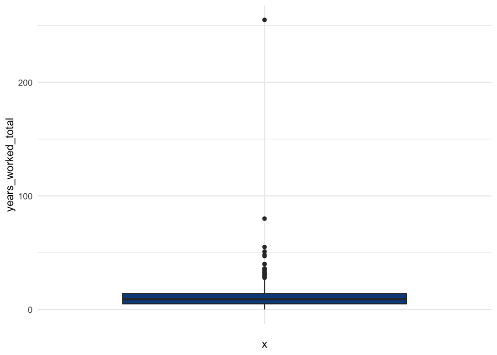

```r
ggplot(df) +
  aes(x = "", y = years_worked_total) +
  geom_boxplot(fill = "#0c4c8a") +
  theme_minimal()
```

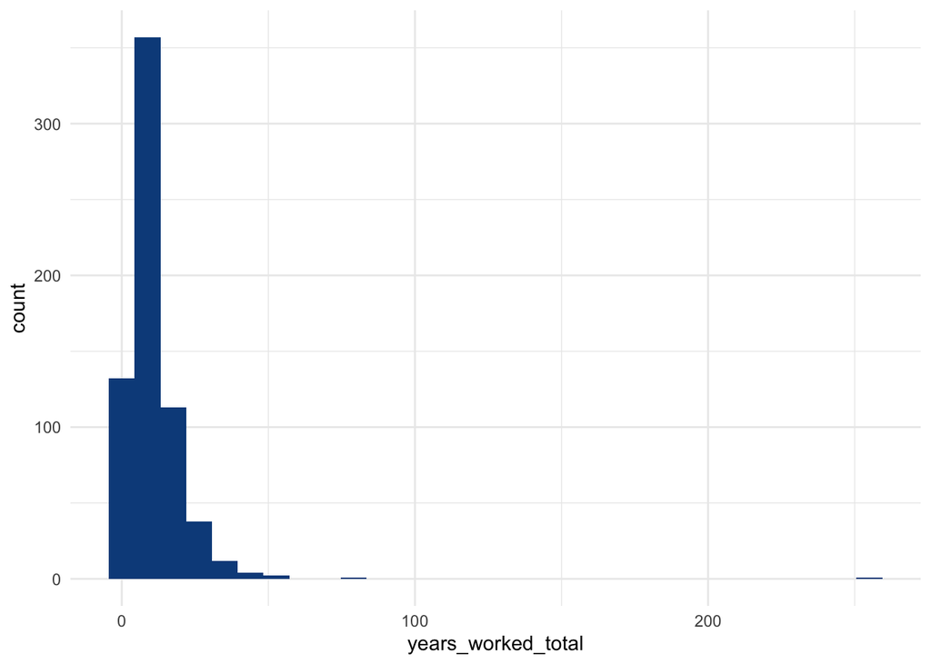

```r
ggplot(df) +
  aes(x = years_worked_total) +
  geom_histogram(fill = "#0c4c8a") +
  theme_minimal()
```

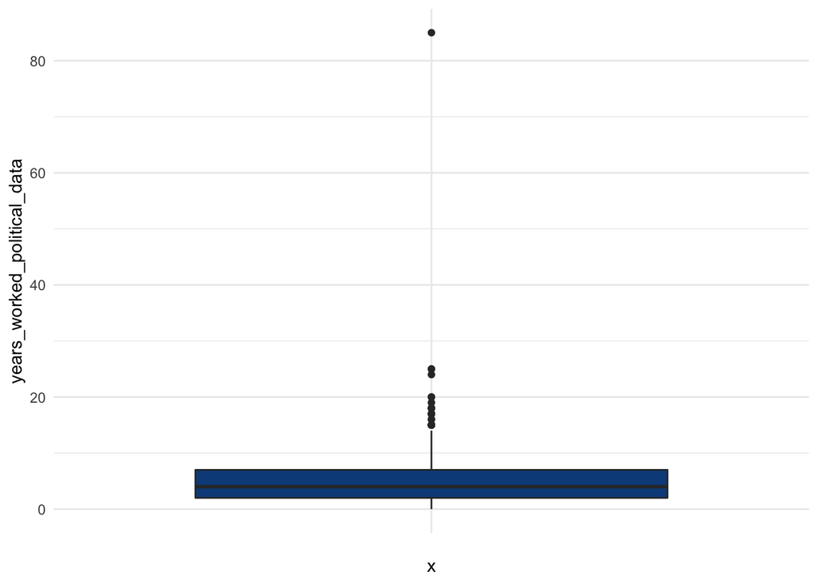

```r
ggplot(df) +
  aes(x = "", y = years_worked_political_data) +
  geom_boxplot(fill = "#0c4c8a") +
  theme_minimal()
```

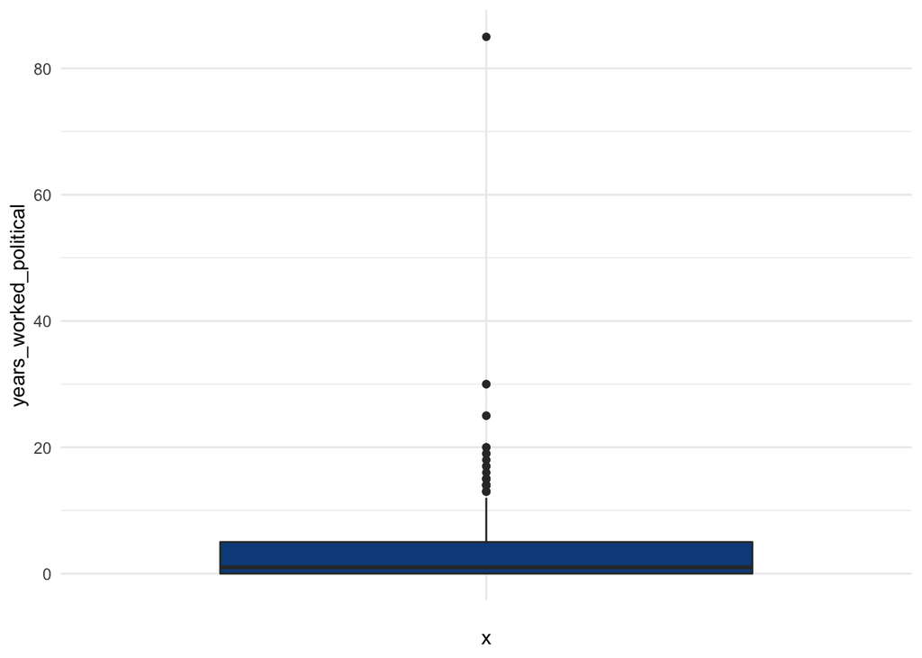

```r
ggplot(df) +
  aes(x = "", y = years_worked_political) +
  geom_boxplot(fill = "#0c4c8a") +
  theme_minimal()
```

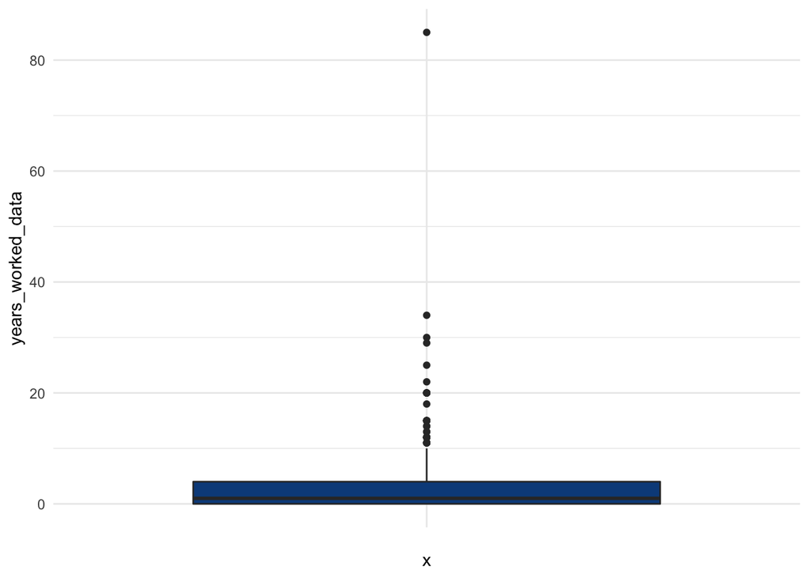

```r
ggplot(df) +
  aes(x = "", y = years_worked_data) +
  geom_boxplot(fill = "#0c4c8a") +
  theme_minimal()
```

```r
# print outliers
sort(boxplot.stats(df$years_worked_total, coef = 2)$out)
```

```
##  [1]  33  33  34  35  35  36  36  36  40  40  47  48  51  55  80 255
```

```r
sort(boxplot.stats(df$years_worked_political_data, coef = 2)$out)
```

```
##  [1] 18 18 18 18 19 20 20 24 25 25 85
```

```r
sort(boxplot.stats(df$years_worked_political, coef = 2)$out)
```

```
##  [1] 16 17 17 18 19 19 20 20 25 25 30 30 85
```

```r
sort(boxplot.stats(df$years_worked_data, coef = 2)$out)
```

```
##  [1] 13 13 14 14 15 15 15 15 15 15 15 18 20 20 20 20 20 20 20 22 25 29 30 34 85
```

```r
# Mark a whole row as NA if:
# All three values are the same
# Any of three values is an outlier with coef = 2x IQR
# age_minus_work < 18
# years_worked_political_data = years_worked_political, and both are above 3

df <- df %>% mutate(
  work_hist_eligible =
    # find all the non-eligible rows, then flip so eligible = TRUE
    !(
      # if any of these conditions are met, the row should not be used
      any(is.na(c_across(cols = cols))) |
        # all columns have the same value
        work_hist_duped == 1 |
        # more years worked than is reasonable
        age_minus_work < 18 |
        # years worked is an extreme outlier
        years_worked_total %in% boxplot.stats(df$years_worked_total, coef = 2)$out |
        years_worked_data %in% boxplot.stats(df$years_worked_data, coef = 3)$out |
        years_worked_political_data %in% boxplot.stats(df$years_worked_political_data, coef = 3)$out |
        years_worked_political %in% boxplot.stats(df$years_worked_political, coef = 3)$out |
        # years worked in politics and in data listed as the same not-small number
        (identical(years_worked_political_data, years_worked_political) &
           years_worked_political_data > 4
        )
    )
)

# visually check data to see it seems reasonable
outliers_all <- df %>%
  filter(work_hist_eligible == FALSE) %>%
  select(
    response_id,
    status,
    starts_with("years_worked"),
    work_hist_duped,
    age_minus_work,
    compensation
  )
```

## Professional Development

Did people only use professional development that they said they had access to?

```r
# Create Helper Objects
pd_df <- df %>%
  select(
    starts_with("prof_dev"),
    - prof_dev_yesno,
    - ends_with("not_used")
  )
pd_types <- stringr::str_split_fixed(colnames(pd_df), ".resp.", 2)[, 2] %>%
  unique()

df <- df %>% ungroup()
```

```r
# Quick Checks
# First Q validation worked correctly, only people who have PD overall used it
tmp2 <- df %>%
  group_by(prof_dev_yesno) %>%
  summarise(
    n = n(),
    across(starts_with("prof_dev"), ~ sum(., na.rm = TRUE))
  )

# overall, there is no category where more people used PD than said they had it
tmp3 <- df %>%
  summarise(
    across(starts_with("prof_dev_available"), ~sum(.x, na.rm = TRUE))
  ) %>%
  tidyr::pivot_longer(cols = everything()) %>%
  transmute(
    name = stringr::str_split_fixed(name, ".resp.", 2)[, 2],
    n_available = value
  )

tmp4 <- df %>%
  summarise(
    across(starts_with("prof_dev_used"), ~ sum(., na.rm = TRUE))) %>%
  tidyr::pivot_longer(cols = everything()) %>%
  transmute(
    name = stringr::str_split_fixed(name, ".resp.", 2)[, 2],
    n_used = value
  ) %>%
  full_join(tmp3, by = "name")
```

```r
recode_pd <- function(dat, pd_type){

  available <- paste0("prof_dev_available.resp.", {{pd_type}})
  used <- paste0("prof_dev_used.resp.", {{pd_type}})

  errs <- dat %>% filter(
    is.na(.data[[available]]),
    .data[[used]] == TRUE
  ) %>% nrow()

  print(paste("There are", errs, "errors for", pd_type, ". Cleaning Now!"))

  dat <- dat %>% mutate(
    tmp = case_when(
      is.na(dat[[available]]) ~ NA,
      dat[[used]] == TRUE ~ TRUE,
      is.na(dat[[used]]) ~ FALSE
  ))

  return(dat$tmp)
}

for(i in seq_along(pd_types)) {

  used <- paste0("prof_dev_used.resp.", pd_types[i])
  df[[used]] <- recode_pd(df, pd_types[i])
}
```

```
## [1] "There are 3 errors for conference_present . Cleaning Now!"
## [1] "There are 4 errors for conference_attend . Cleaning Now!"
## [1] "There are 1 errors for certification . Cleaning Now!"
## [1] "There are 5 errors for trainings_offsite . Cleaning Now!"
## [1] "There are 1 errors for buy_materials . Cleaning Now!"
## [1] "There are 10 errors for trainings_small_group . Cleaning Now!"
## [1] "There are 2 errors for tution_reimbursement . Cleaning Now!"
## [1] "There are 8 errors for other . Cleaning Now!"
```

## Missingness

# Write Clean Data To GoogleDrive

First, write the dataframes to a local directory via the `here` package. Make sure your .gitignore is set to ignore the main results df, since it includes PII, but the other data files can be sent to git.

Since we can’t send the results to git, we’ll upload to google drive instead.

```r
df %>% ungroup()
```

[output not shown]

[output cut: 35 more lines]

[output not shown]

```r
readr::write_csv(
  df,
  here::here("data", "survey_responses.csv")
)

readr::write_csv(
  compensation_bin_crosswalk,
  here::here("data", "compensation_bin_crosswalk.csv")
)

readr::write_csv(
  rpp,
  here::here("data", "rpp_zip_clean.csv")
)

# write a cleaned up version of the name helper table
name_helper <- name_helper %>%
  rename(
   response_name = sub_response,
   response_name_short = col_name_clean
  ) %>% select(-col_name_helper)

readr::write_csv(
  name_helper,
  here::here("data", "col_name_helper.csv")
)
```

```r
# upload results file to google drive, since we can't put it in git
# and the google sheets upload was causing issues/ misaligned columns
file <- googledrive::drive_find("survey_responses_clean.csv", n_max = 1)
```

[output not shown]

[output not shown]

[output not shown]

[output not shown]

```r
googledrive::drive_update(
  googledrive::as_id(file),
  here::here("data", "survey_responses.csv"),
  )
```

```
## File updated:
##   * survey_responses_clean.csv: 1urZL8JCFdjFDTARpClQbCtX41NV3TSML
```